# Table of Contents

```python
import numpy as np                # linear algebra
import pandas as pd               # data frames

import matplotlib.pyplot as plt   # visualizations
import seaborn as sns             # visualizations
%matplotlib inline

#scipy
from scipy import stats
from scipy.stats.distributions import chi2

# statsmodels
import statsmodels.api as sm
import statsmodels.stats.api as sms
import statsmodels.formula.api as smf
import statsmodels.graphics.tsaplots as sgt
import statsmodels.tsa.stattools as sts
import statsmodels.tsa.api as smt

from statsmodels.graphics.tsaplots import plot_acf, plot_pacf
from statsmodels.graphics.gofplots import ProbPlot
from statsmodels.compat import lzip
from statsmodels.stats.outliers_influence import OLSInfluence
from statsmodels.tsa.api import ExponentialSmoothing
from statsmodels.tsa.seasonal import seasonal_decompose
from statsmodels.tsa.stattools import adfuller, kpss
from statsmodels.tsa.arima_model import ARMA
from statsmodels.tsa.arima_model import ARIMA
from statsmodels.tsa.api import SARIMAX
from statsmodels.stats.diagnostic import acorr_ljungbox

# sklearn
from sklearn import datasets, linear_model
from sklearn.linear_model import LinearRegression
from sklearn.metrics import mean_squared_error, r2_score
from sklearn.model_selection import train_test_split

from math import sqrt
from pmdarima.arima import auto_arima
```

```python
import warnings
warnings.filterwarnings("ignore")
```

```python
# thousands separator ',' and 2 décimals
pd.options.display.float_format = '{:.1f}'.format
```

# Data wrangling + Descriptive analysis

## Data file eCO2mix

```python
# import data
data = pd.read_excel('data/eCO2mix_RTE_energie_M.xlsx',usecols=['Mois','Qualité','Territoire','Consommation totale'],encoding="utf-8")
data.head(1)
```

|  | Mois | Qualité | Territoire | Consommation totale |
| --- | --- | --- | --- | --- |
| 0 | 0000-00 | Données consolidées | Grand-Est | 3364 |

### Selecting data for Territoire = France

```python
# sélection de 'France'
cvl=data[data['Territoire']=='France'].reset_index(drop=True)
# Rename
cvl.rename(columns={'Mois': 'period','Consommation totale': 'conso'},
           inplace = True)
print('Qualité :',cvl['Qualité'].unique())
```

```
Qualité : ['Données définitives' 'Données consolidées']
```

```python
# drop cols
cvl.drop(['Qualité', 'Territoire'], axis=1, inplace=True)
# supress incorrect/useless values
cvl = cvl[cvl['conso'] != 0]
cvl = cvl[cvl['period'] != '0000-00']
cvl = cvl[cvl.period < '2019-01']
# dtypes convertion
cvl = cvl.astype({"conso":int})
```

### Setting time-serie

```python
# time-serie
cvl.period=pd.to_datetime(cvl.period, format="%Y-%m-%d", dayfirst=False)
# set index = period
cvl.set_index('period', inplace=True)
# set périod = month
cvl=cvl.to_period('M')
cvl.head(2)
```

| period | conso |
| --- | --- |
| 2010-01 | 56342 |
| 2010-02 | 48698 |

## Data file DJU Paris

> DJU = Données Journalières Unifiées

### Data consolidation

```python
# DJU Paris
dju= pd.read_excel('data/DJUP.xlsx')
dju = dju[dju.Year != 2009]
dju.rename(columns={'JAN': 1,'FÉV': 2,'MAR': 3,'AVR': 4,'MAI': 5,'JUN': 6,'JUI': 7,'AOÛ': 8,
                    'SEP': 9,'OCT': 10,'NOV': 11,'DÉC': 12},  inplace = True)
dju
```

|  | Year | 1 | 2 | 3 | 4 | 5 | 6 | 7 | 8 | 9 | 10 | 11 | 12 |
| --- | --- | --- | --- | --- | --- | --- | --- | --- | --- | --- | --- | --- | --- |
| 0 | 2018 | 303.4 | 432.6 | 314.3 | 119.7 | 55.9 | 8.1 | 0.0 | 3.3 | 34.3 | 122.4 | 282.5 | 325.9 |
| 1 | 2017 | 467.9 | 278.4 | 206.1 | 182.6 | 75.0 | 9.4 | 1.0 | 6.8 | 62.6 | 99.4 | 282.6 | 369.0 |
| 2 | 2016 | 364.4 | 321.6 | 321.1 | 212.1 | 88.1 | 27.5 | 5.7 | 3.2 | 11.7 | 176.0 | 285.6 | 390.8 |
| 3 | 2015 | 392.0 | 365.7 | 275.5 | 141.1 | 91.5 | 15.8 | 6.9 | 6.1 | 71.9 | 176.9 | 195.0 | 248.1 |
| 4 | 2014 | 324.4 | 281.9 | 223.9 | 135.5 | 100.2 | 19.1 | 8.3 | 19.3 | 16.0 | 92.3 | 222.6 | 368.2 |
| 5 | 2013 | 429.2 | 402.2 | 376.6 | 209.5 | 158.4 | 43.6 | 0.6 | 5.0 | 41.5 | 105.0 | 303.9 | 349.5 |
| 6 | 2012 | 336.0 | 435.9 | 201.9 | 230.3 | 83.3 | 35.0 | 12.4 | 2.4 | 58.0 | 154.6 | 296.2 | 345.9 |
| 7 | 2011 | 392.0 | 304.8 | 243.1 | 77.6 | 43.4 | 31.4 | 15.0 | 11.9 | 23.2 | 127.6 | 226.6 | 312.7 |
| 8 | 2010 | 499.2 | 371.4 | 294.5 | 165.3 | 140.9 | 22.6 | 0.0 | 11.1 | 52.3 | 172.2 | 310.0 | 512.0 |

```python
# processing
x=dju[dju.Year==2018]
a=x.melt().reset_index(drop=True)
a['Month']= 2018

x=dju[dju.Year==2017]
b=x.melt().reset_index(drop=True)
b['Month']= 2017

x=dju[dju.Year==2016]
c=x.melt().reset_index(drop=True)
c['Month']= 2016

x=dju[dju.Year==2015]
d=x.melt().reset_index(drop=True)
d['Month']= 2015

x=dju[dju.Year==2014]
e=x.melt().reset_index(drop=True)
e['Month']= 2014

x=dju[dju.Year==2013]
f=x.melt().reset_index(drop=True)
f['Month']= 2013

x=dju[dju.Year==2012]
g=x.melt().reset_index(drop=True)
g['Month']= 2012

x=dju[dju.Year==2011]
h=x.melt().reset_index(drop=True)
h['Month']= 2011

x=dju[dju.Year==2010]
i=x.melt().reset_index(drop=True)
i['Month']= 2010

frames = [a,b,c,d,e,f,g,h,i]
result = pd.concat(frames)
result = result[result.variable != 'Year']

result.rename(columns={'variable':'month','value':'dju','Month':'year'},  inplace = True)
result['period']=result['year'].apply(str) + '-' + result['month'].apply(str)

result.head(2)
```

|  | month | dju | year | period |
| --- | --- | --- | --- | --- |
| 1 | 1 | 303.4 | 2018 | 2018-1 |
| 2 | 2 | 432.6 | 2018 | 2018-2 |

### Setting time-serie

```python
# time-serie
result.period=pd.to_datetime(result.period, format="%Y-%m-%d", dayfirst=False)

# set index = time-serie
result.set_index('period', inplace=True)
result=result[['dju']]

# set period = month
DJU=result.to_period('M')

print(DJU.info())
DJU.head(3)
```

```
<class 'pandas.core.frame.DataFrame'>
PeriodIndex: 108 entries, 2018-01 to 2010-12
Freq: M
Data columns (total 1 columns):
dju    108 non-null float64
dtypes: float64(1)
memory usage: 1.7 KB
None
```

| period | dju |
| --- | --- |
| 2018-01 | 303.4 |
| 2018-02 | 432.6 |
| 2018-03 | 314.3 |

## Data consolidation

### Merge

```python
# merge
lr=pd.merge(cvl, DJU, left_index=True, right_index=True)
print(lr.info())
lr.head(1)
```

```
<class 'pandas.core.frame.DataFrame'>
PeriodIndex: 108 entries, 2010-01 to 2018-12
Freq: M
Data columns (total 2 columns):
conso    108 non-null int32
dju      108 non-null float64
dtypes: float64(1), int32(1)
memory usage: 2.1 KB
None
```

| period | conso | dju |
| --- | --- | --- |
| 2010-01 | 56342 | 499.2 |

### Data visualisation

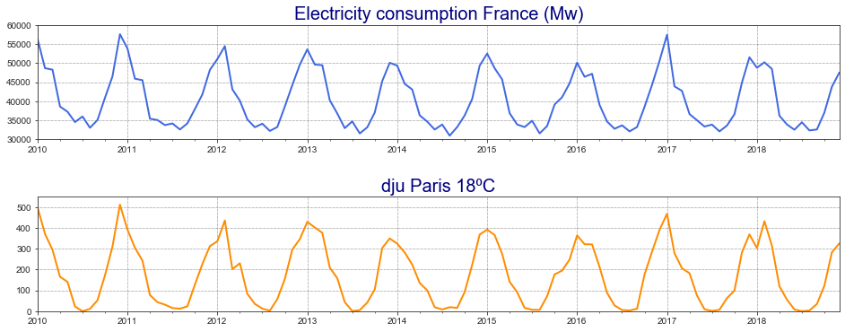

```python
sns.set_style("ticks")
fig, axs = plt.subplots(2, sharex=True, figsize=[28,5])
fig.tight_layout()
plt.subplots_adjust(hspace=0.5)

plt.subplot(221)
# Consommation France (Mwh)
lr.conso.plot(legend=None, linewidth=2, color='royalblue')
plt.grid(linestyle=':', color='black',linewidth=0.5)
plt.title("Electricity consumption France (Mw)", size = 20, color='navy')
plt.xlabel('')
plt.ylim(30000,60000)

plt.subplot(223)
# DJU Paris
lr.dju.plot(legend=None, linewidth=2, color='darkorange')
plt.grid(linestyle=':', color='black',linewidth=0.5)
plt.title("dju Paris 18ºC", size = 20, color='navy')
plt.xlabel('')
plt.ylim(0,550)

plt.savefig('img/1.3 conso_dju.png', dpi=120, bbox_inches='tight')
plt.show()
```

> - Strong correlation

# Temperature normalization

## Linear regression Electric consumption France vs dju Paris 18ºC

```python
y = lr.iloc[:,0]
x=lr.iloc[:,1]
x_constant = sm.add_constant(x, prepend=False)

lin_reg= sm.OLS(y,x_constant).fit()
res=lin_reg.resid # residuals
predict=lin_reg.predict(x_constant)

print(lin_reg.summary())
```

```
                            OLS Regression Results
==============================================================================
Dep. Variable:                  conso   R-squared:                       0.956
Model:                            OLS   Adj. R-squared:                  0.955
Method:                 Least Squares   F-statistic:                     2282.
Date:                Mon, 27 Jan 2020   Prob (F-statistic):           1.60e-73
Time:                        11:14:49   Log-Likelihood:                -944.71
No. Observations:                 108   AIC:                             1893.
Df Residuals:                     106   BIC:                             1899.
Df Model:                           1
Covariance Type:            nonrobust
==============================================================================
                 coef    std err          t      P>|t|      [0.025      0.975]
------------------------------------------------------------------------------
dju           48.2471      1.010     47.768      0.000      46.245      50.250
const       3.188e+04    231.396    137.753      0.000    3.14e+04    3.23e+04
==============================================================================
Omnibus:                        0.491   Durbin-Watson:                   1.890
Prob(Omnibus):                  0.782   Jarque-Bera (JB):                0.620
Skew:                           0.141   Prob(JB):                        0.733
Kurtosis:                       2.758   Cond. No.                         358.
==============================================================================

Warnings:
[1] Standard Errors assume that the covariance matrix of the errors is correctly specified.
```

## Diagnostics

### Correlation: Pearson’s Correlation Coefficient

Tests whether two samples have a linear relationship

**Assumptions:**

- Observations in each sample are independent and identically distributed (iid).
- Observations in each sample are normally distributed.
- Observations in each sample have the same variance.
- H0: the two samples are independent.
- H1: there is a dependency between the samples.

source : https://machinelearningmastery.com/statistical-hypothesis-tests-in-python-cheat-sheet/

```python
from scipy.stats import pearsonr
data1 = lr.conso
data2 = lr.dju
stat, p = pearsonr(data1, data2)
print('stat=%.3f, p=%.3f' % (stat, p))
if p > 0.05:
    print('Probably independent')
else:
    print('Probably dependent')
```

```
stat=0.978, p=0.000
Probably dependent
```

### Linearity

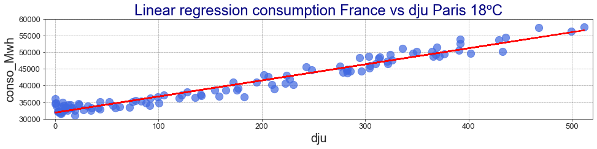

```python
sns.set_style("ticks")
plt.figure(figsize=(16,3))

# scatter plot
plt.plot(x, predict, lw=2, c='red', label ='regression line', alpha =1)
plt.scatter(x, y,s=150, color='royalblue', alpha=0.7)

# Label the df
plt.title('Linear regression consumption France vs dju Paris 18ºC', fontsize = 24, color='navy')
plt.grid(linestyle=':', color='black',linewidth=0.5)
plt.xlabel('dju', fontsize = 20)
plt.ylabel('conso_Mwh', fontsize = 20)
plt.ylim(30000,60000)
plt.xlim(-10,520)
plt.yticks(fontsize=13)
plt.xticks(fontsize=13)

plt.savefig('img/2.2 lin_reg.png', dpi=120, bbox_inches='tight')
plt.show()
```

> - The model is linear

### Normality: Shapiro-Wilk Test

Tests whether a data sample has a Gaussian distribution

**Assumptions:** Observations in each sample are independent and identically distributed (iid)

- H0: the sample has a Gaussian distribution.
- H1: the sample does not have a Gaussian distribution

https://machinelearningmastery.com/statistical-hypothesis-tests-in-python-cheat-shee

```python
# Shapiro-Wilk Normality Test
from scipy.stats import shapiro
data = lin_reg.resid
stat, p = shapiro(data)
print('stat=%.3f, p=%.3f' % (stat, p))
if p > 0.05:
    print('Probably Gaussian')
else:
    print('Probably not Gaussian')
```

```
stat=0.995, p=0.950
Probably Gaussian
```

### Graphic checking

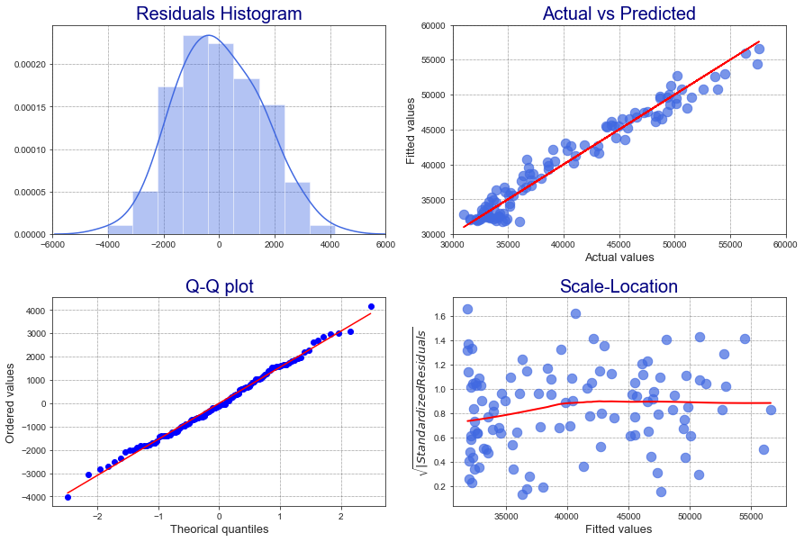

```python
sns.set_style("ticks")

fig, ax = plt.subplots(figsize=[12,8])
fig.tight_layout()
plt.subplots_adjust(left=None, bottom=None, right=None, top=None, wspace=None, hspace=0.3)

# Histogram
plt.subplot(221)
plt.grid(linestyle=':', color='black',linewidth=0.5)
sns.distplot(lin_reg.resid, color='royalblue')
plt.title("Residuals Histogram", size=20, color="navy")
plt.xlim(-6000,6000)

# Actual vs Predicted
plt.subplot(222)
# Data
endog = lin_reg.model.endog
fitted_values = lin_reg.fittedvalues
# Actual vs Predict plot
plt.scatter(endog, fitted_values, color='royalblue', alpha=0.7, s=110)
plt.plot(endog, endog, c='red')
plt.grid(linestyle=':', color='black',linewidth=0.5)
plt.xlabel("Actual values", fontsize=13)
plt.ylabel("Fitted values", fontsize=13)
plt.title("Actual vs Predicted", size=20, color="navy")
plt.xlim(30000,60000)
plt.ylim(30000,60000)

# Q-Q plot
plt.subplot(223)
plt.grid(linestyle=':', color='black',linewidth=0.5)
stats.probplot(lin_reg.resid, plot=plt, fit=True)
plt.title("Q-Q plot", fontsize=20, color='navy')
plt.xlabel("Theorical quantiles", fontsize=13)
plt.ylabel("Ordered values", fontsize=13)

#Scale-Location
plt.subplot(224)
# fitted values (constante pour l'intercept)
model_fitted_y = lin_reg.fittedvalues
# normalized residuals
model_norm_residuals = lin_reg.get_influence().resid_studentized_internal
# absolute squared normalized residuals
model_norm_residuals_abs_sqrt = np.sqrt(np.abs(model_norm_residuals))
# représentation graphique des squared standardized residuals
plt.scatter(model_fitted_y, model_norm_residuals_abs_sqrt, color='royalblue', alpha=0.7, s=110)
sns.regplot(model_fitted_y, model_norm_residuals_abs_sqrt,
            scatter=False, ci=False, lowess=True,
            line_kws={'color': 'red', 'lw': 2, 'alpha':1})
plt.grid(linestyle=':', color='black',linewidth=0.5)
plt.title('Scale-Location', size=20, color="navy")
plt.xlabel('Fitted values', fontsize=13)
plt.ylabel('$\sqrt{|Standardized Residuals}$', fontsize=13)


plt.savefig('img/2.2 reg_lin_check.png', dpi=120, bbox_inches='tight')
plt.show()
```

## Normalization of the consumption to 18ºC with the dju dataset

**We have 2 sets of data:**

- A total monthly consumption of electricity over 9 years
- The delta of ºC to reach a constant temperature of 18ºC over 9 years to balance electric consumption due to heating
- Total electric consumption = heating consumption + other consumption
- Normalized electric consumption 18ºC = Total electric consumption - heating consumption = other consumption
- The linear regression conso vs dju will allow us to estimate the increase of the total consumption for 1 dju

$$ conso = α + 𝛽.dju + ϵ $$$$ consocor = conso - 𝛽.dju = α + ϵ $$

### Calculus

```python
# Correction
𝛽 = lin_reg.params['dju']
cvl2=pd.DataFrame(lr["conso"]- lr['dju']*𝛽)

# Rename
cvl2.rename(columns={0:'conso_cor'},  inplace = True)
cvl2.head(2)
```

| period | conso_cor |
| --- | --- |
| 2010-01 | 32257.1 |
| 2010-02 | 30779.0 |

```python
# merge
conso=pd.merge(data1, cvl2, left_index=True, right_index=True)
# Rename
conso.rename(columns={'conso': 'conso_raw'},  inplace = True)
conso.head(2)
```

| period | conso_raw | conso_cor |
| --- | --- | --- |
| 2010-01 | 56342 | 32257.1 |
| 2010-02 | 48698 | 30779.0 |

### Data visualization

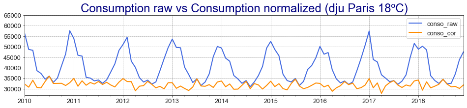

```python
# Graphic
conso.plot(figsize = (16,3), linewidth=2, color=['royalblue','darkorange'])
plt.grid(color="black", linestyle=':', linewidth=0.5)
plt.title("Consumption raw vs Consumption normalized (dju Paris 18ºC)", fontsize=24, color='navy')
plt.xlabel('')
plt.ylim(27000,65000)
plt.xticks(fontsize=13)
plt.yticks(fontsize=13)
plt.legend(fontsize=13)

plt.savefig('img/2.3 conso_raw vs conso_cor.png', dpi=120, bbox_inches='tight')
plt.show()
```

# Consumption desaizonalisation – Moving Average (MA)

Considering the curve of the normalized electric consumption, we will chose the **additive model** (constant range around the trend),  
rather than the multiplicative model (range proportional to the trend)

- **A time serie has 3 componants:** Trend, Seasonality, Residual
- **Aim of desaisonnalization:** Absorb seasonality, conserve the trend and minimize residual variance

## Seasonality - decomposition

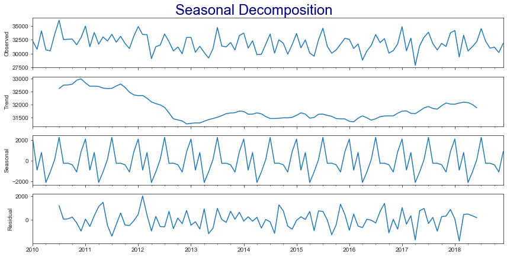

```python
# decomposition
conso.index=lr.index.to_timestamp()
s_dec_additive = seasonal_decompose(conso.conso_cor, model = "additive", freq=12)

plt.rcParams["figure.figsize"] = [12,6]
s_dec_additive.plot()
plt.suptitle('Seasonal Decomposition', fontsize=24, color='navy', y=1.03)
plt.xlabel('')

plt.savefig('img/3.1 decomposition.png', dpi=120, bbox_inches='tight')
plt.show()
```

> - **Observed** shows a constant range around the trend => additive model
> - **Trend** is non-linear (flat, ascending or descending)
> - **Seasonal** shows a 6 and a 12 months periodicity. We choose s=12 based on a yearly weather cycle
> - **Residual** seems to be white noise

## Desaisonalization by Moving Average (MA)

```python
# Rolling average
ra=conso.conso_cor.rolling(window=12, center=True).mean()
```

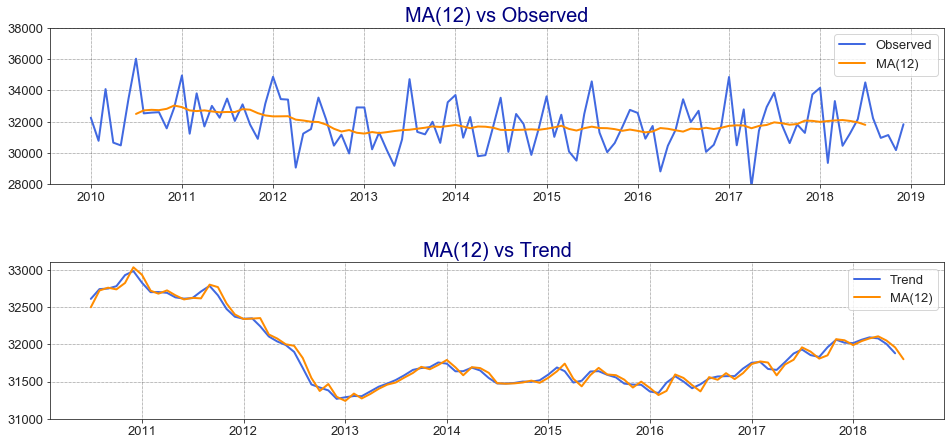

```python
sns.set_style("ticks")
fig, ax = plt.subplots(2, sharex=True, figsize=[28,6])
fig.tight_layout()
plt.subplots_adjust(left=None, bottom=None, right=None, top=None, wspace=None, hspace=0.5)

plt.subplot(2,2,1)
plt.grid(linestyle=':', color='black', linewidth=0.5)
plt.plot(conso.conso_cor, linewidth=2, label='Observed', color='royalblue')
plt.plot(ra, linewidth=2,label='MA(12)', color='darkorange')
plt.title('MA(12) vs Observed', fontsize = 20, color='navy')
plt.xticks(fontsize=13)
plt.yticks(fontsize=13)
plt.legend(fontsize=13)
plt.ylim(28000,38000)

plt.subplot(2,2,3)
plt.grid(linestyle=':', color='black', linewidth=0.5)
plt.plot(s_dec_additive.trend, linewidth=2, label='Trend', color='royalblue')
plt.plot(ra, linewidth=2, label='MA(12)', color='darkorange')
plt.title('MA(12) vs Trend', fontsize = 20, color='navy')
plt.xticks(fontsize=13)
plt.yticks(fontsize=13)
plt.legend(fontsize=13)
plt.ylim(31000,33100)

plt.savefig('img/3.2 moving_average.png', dpi=120, bbox_inches='tight')
plt.show()
```

> - The MA(12) desaisonalization is efficient, very close to the Trend obtained during the decomposition of the time-serie
> - The influence of residuals is minimal
> - The model is graphically reliable

## Stationarity

### Augmented Dickey-Fuller Unit Root Test

Tests whether a time series has a unit root, e.g. has a trend or more generally is autoregressive.

**Assumptions :** Observations in are temporally ordered

- H0: a unit root is present (series is non-stationary).
- H1: a unit root is not present (series is stationary).

Source: https://machinelearningmastery.com/statistical-hypothesis-tests-in-python-cheat-sheet/

```python
# Augmented Dickey-Fuller unit root test
from statsmodels.tsa.stattools import adfuller

data = conso.conso_cor
stat, p, lags, obs, crit, t = adfuller(data)
print('stat=%.3f, p=%.3f' % (stat, p))
if p > 0.05:
    print('Probably not Stationary')
else:
    print('Probably Stationary')
```

```
stat=-1.807, p=0.377
Probably not Stationary
```

### Kwiatkowski-Phillips-Schmidt-Shin

Tests whether a time series is trend stationary or not.

**Assumptions :** Observations in are temporally ordered

- H0: the time series is not trend-stationary.
- H1: the time series is trend-stationary.

Source: https://machinelearningmastery.com/statistical-hypothesis-tests-in-python-cheat-sheet/

```python
# Kwiatkowski-Phillips-Schmidt-Shin test
from statsmodels.tsa.stattools import kpss
data = conso.conso_cor
stat, p, lags, crit = kpss(data)
print('stat=%.3f, p=%.3f' % (stat, p))
if p > 0.05:
    print('Probably not Stationary')
else:
    print('Probably Stationary')
```

```
stat=0.351, p=0.098
Probably not Stationary
```

# Consumption forecast

## Holt-Winters Method

### Splitting data

```python
# Training model = conso_cor - 12 last months (2018)
df = conso.conso_cor.iloc[:-12]
# Testing model = 12 last months (2018)
df_test = conso.conso_cor.iloc[-12:]
```

### Run and visualize

```python
# Triple smoothing alpha, beta, gamma = Holt-Winters
hw = ExponentialSmoothing(df, seasonal_periods=12, trend='add', seasonal='add').fit()
hw_pred = hw.forecast(12)

print(hw.summary())

# performances indexes
y_true_hw = df_test
y_pred_hw = hw_pred

# Root mean square error (RMSE)
rmse = sqrt(mean_squared_error(y_true_hw,y_pred_hw))
print("RMSE HOLT-WINTERS:", round(rmse,3))
# Mean absolute percentage error (MAPE)
mape = np.mean(np.abs((y_true_hw - y_pred_hw) / y_true_hw)) * 100
print("MAPE HOLT-WINTERS:  ", round(mape,3))
```

```
                       ExponentialSmoothing Model Results
================================================================================
Dep. Variable:                    endog   No. Observations:                   96
Model:             ExponentialSmoothing   SSE                       69197646.131
Optimized:                         True   AIC                           1326.860
Trend:                         Additive   BIC                           1367.890
Seasonal:                      Additive   AICC                          1335.744
Seasonal Periods:                    12   Date:                 Mon, 27 Jan 2020
Box-Cox:                          False   Time:                         11:15:00
Box-Cox Coeff.:                    None
=================================================================================
                          coeff                 code              optimized
---------------------------------------------------------------------------------
smoothing_level               0.1345330                alpha                 True
smoothing_slope              6.2227e-21                 beta                 True
smoothing_seasonal           3.7336e-20                gamma                 True
initial_level                 33571.754                  l.0                 True
initial_slope                 0.1529298                  b.0                 True
initial_seasons.0             575.72657                  s.0                 True
initial_seasons.1            -1996.4634                  s.1                 True
initial_seasons.2            -393.84469                  s.2                 True
initial_seasons.3            -3356.8185                  s.3                 True
initial_seasons.4            -2477.0031                  s.4                 True
initial_seasons.5            -1026.3391                  s.5                 True
initial_seasons.6             1030.7377                  s.6                 True
initial_seasons.7            -1465.6341                  s.7                 True
initial_seasons.8            -1463.3483                  s.8                 True
initial_seasons.9            -1615.6375                  s.9                 True
initial_seasons.10           -2302.7919                 s.10                 True
initial_seasons.11           -353.93347                 s.11                 True
---------------------------------------------------------------------------------
RMSE HOLT-WINTERS: 765.904
MAPE HOLT-WINTERS:   2.042
```

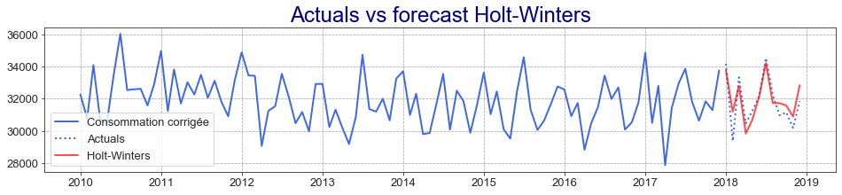

```python
# Visualization
fig, ax = plt.subplots(figsize=(16,3))
plt.grid(color="black", linestyle=':', linewidth=0.5)

plt.plot(df, label='Consommation corrigée', linewidth=2, color='royalblue', alpha=1)
plt.plot(df_test, label='Actuals', linewidth=2, color='royalblue', linestyle=':', alpha=1)
plt.plot(df_test.index, hw_pred, label='Holt-Winters', linewidth=2, color='red', alpha=0.7)

plt.legend(loc="lower left",fontsize=13)
plt.yticks(fontsize=13)
plt.xticks(fontsize=13)
plt.title("Actuals vs forecast Holt-Winters", fontsize=24, color='navy')

plt.savefig('img/4.1 holt_winters.png', dpi=120, bbox_inches='tight')
plt.show()
```

### Model performance

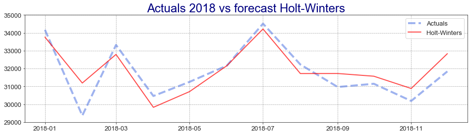

```python
fig, ax = plt.subplots(figsize=(16,4))
plt.grid(color="black", linestyle=':', linewidth=0.5)
plt.plot(df_test, label='Actuals', linewidth=4, color='royalblue',linestyle='--', alpha=0.5)
plt.plot(df_test.index, hw_pred, label='Holt-Winters', linewidth=2, color='red', alpha=0.7)
plt.title("Actuals 2018 vs forecast Holt-Winters", fontsize=24, color='navy')

plt.ylim(29000,35000)
plt.legend(loc="uper right",fontsize=13)
plt.yticks(fontsize=13)
plt.xticks(fontsize=13)

plt.savefig('img/4.1 holt_winters2.png', dpi=120, bbox_inches='tight')
plt.show()
```

```python
# Shapiro-Wilk Normality Test
data = hw.resid
stat, p = shapiro(data)
print('stat=%.3f, p=%.3f' % (stat, p))
if p > 0.05:
    print('Probably Gaussian')
else:
    print('Probably not Gaussian')
```

```
stat=0.984, p=0.312
Probably Gaussian
```

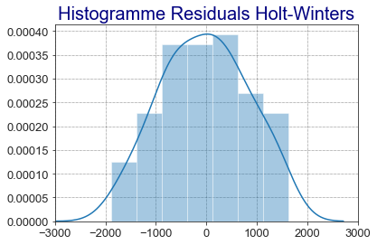

```python
# Histogramme
plt.figure(figsize=(6,4))
sns.distplot(hw.resid)
plt.grid(linestyle=':', color='black',linewidth=0.5)
plt.title("Histogramme Residuals Holt-Winters", size=20, color="navy")
plt.xticks(fontsize=13)
plt.yticks(fontsize=13)
plt.xlim(-3000,3000)
plt.show()
```

## Forecast: SARIMA method

### Definitions

Configuring a SARIMA requires selecting hyperparameters for both the trend and seasonal elements of the series.

**Trend Elements**  
There are three trend elements that require configuration  
They are the same as the ARIMA model

- p: Trend autoregression order (AR)
- d: Trend difference order.
- q: Trend moving average order (MA)

**There are four seasonal elements that are not part of ARIMA that must be configured**

- P: Seasonal autoregressive order.
- D: Seasonal difference order.
- Q: Seasonal moving average order.
- m: The number of time steps for a single seasonal period.

**Together, the notation for an SARIMA model is specified as:**

- SARIMA(p,d,q)(P,D,Q)m

source : https://machinelearningmastery.com/sarima-for-time-series-forecasting-in-python/

### ACF and PACF

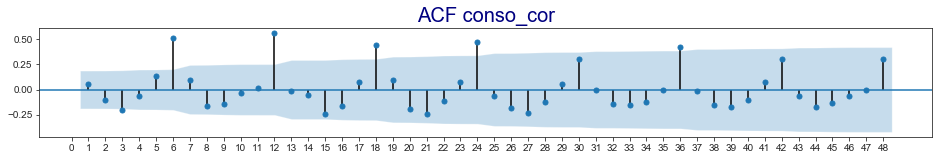

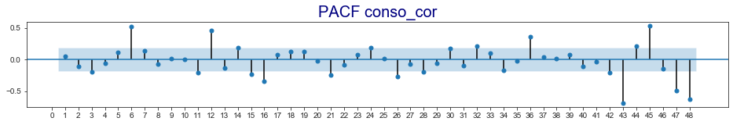

```python
plt.rcParams["figure.figsize"] = [16,2]
acf = sgt.plot_acf(conso.conso_cor, zero=False, lags=48)
plt.title("ACF conso_cor", size=20, color='navy')
plt.xticks(np.arange(0,49, step=1))

pacf = sgt.plot_pacf(conso.conso_cor, zero=False, lags=48)
plt.title("PACF conso_cor", size=20, color='navy')
plt.xticks(np.arange(0,49, step=1))

plt.savefig('img/4.2 ACF_PACF.png', dpi=120, bbox_inches='tight')
plt.show()
```

### Stationnarity

**Augmented Dickey-Fuller Unit Root Test**  
Tests whether a time series has a unit root, e.g. has a trend or more generally is autoregressive.

**Assumptions:** Observations in are temporally ordered

- H0: a unit root is present (series is non-stationary).
- H1: a unit root is not present (series is stationary).

```python
# Augmented Dickey-Fuller unit root test
data = conso.conso_cor
stat, p, lags, obs, crit, t = adfuller(data)
print('stat=%.3f, p=%.3f' % (stat, p))
if p > 0.05:
    print('Probably not Stationary')
else:
    print('Probably Stationary')
```

```
stat=-1.807, p=0.377
Probably not Stationary
```

**Kwiatkowski-Phillips-Schmidt-Shin**  
Tests whether a time series is trend stationary or not.

**Assumptions :** Observations in are temporally ordered

- H0: the time series is not trend-stationary.
- H1: the time series is trend-stationary.

```python
# Kwiatkowski-Phillips-Schmidt-Shin test
from statsmodels.tsa.stattools import kpss
data = conso.conso_cor
stat, p, lags, crit = kpss(data)
print('stat=%.3f, p=%.3f' % (stat, p))
if p > 0.05:
    print('Probably not Stationary')
else:
    print('Probably Stationary')
```

```
stat=0.351, p=0.098
Probably not Stationary
```

- ACF shows a slow decreasing (non-stationarity) for multiples of 6 and 12. We expect a yearly seasonal cycle. We try directly the differenciation (𝐼−𝐵12)

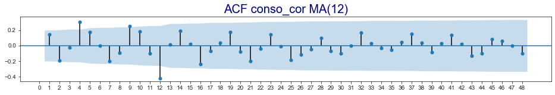

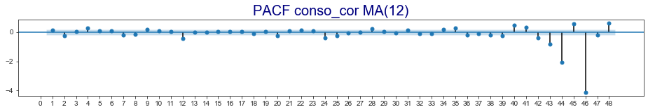

```python
plt.rcParams["figure.figsize"] = [16,2]
data_12 = conso.conso_cor - conso.conso_cor.shift(12)
acf_12 = sgt.plot_acf(data_12.dropna(), zero=False, lags=48)
plt.title("ACF conso_cor MA(12)", size=20, color='navy')
plt.xticks(np.arange(0,49, step=1))

pacf_12 = sgt.plot_pacf(data_12.dropna(), zero=False, lags=48)
plt.title("PACF conso_cor MA(12)", size=20, color='navy')
plt.xticks(np.arange(0,49, step=1))
plt.show()
```

```python
model_ma_12 = ARMA(conso.conso_cor, order=(0,2))
results_ma_12 = model_ma_12.fit()
print(results_ma_12.summary().tables[0])
print(results_ma_12.summary().tables[1])
```

```
                              ARMA Model Results
==============================================================================
Dep. Variable:              conso_cor   No. Observations:                  108
Model:                     ARMA(0, 2)   Log Likelihood                -944.012
Method:                       css-mle   S.D. of innovations           1512.949
Date:                Mon, 27 Jan 2020   AIC                           1896.025
Time:                        11:15:04   BIC                           1906.753
Sample:                    01-01-2010   HQIC                          1900.375
                         - 12-01-2018
==============================================================================
===================================================================================
                      coef    std err          z      P>|z|      [0.025      0.975]
-----------------------------------------------------------------------------------
const            3.188e+04    134.230    237.487      0.000    3.16e+04    3.21e+04
ma.L1.conso_cor     0.0222      0.100      0.223      0.824      -0.173       0.218
ma.L2.conso_cor    -0.1020      0.094     -1.083      0.281      -0.287       0.083
===================================================================================
```

```python
# Augmented Dickey-Fuller unit root test
data = data_12.dropna()
stat, p, lags, obs, crit, t = adfuller(data)
print('stat=%.3f, p=%.3f' % (stat, p))
if p > 0.05:
    print('Probably not Stationary')
else:
    print('Probably Stationary')
```

```
stat=-3.035, p=0.032
Probably Stationary
```

```python
# Kwiatkowski-Phillips-Schmidt-Shin test
data = data_12.dropna()
stat, p, lags, crit = kpss(data)
print('stat=%.3f, p=%.3f' % (stat, p))
if p > 0.05:
    print('Probably not Stationary')
else:
    print('Probably Stationary')
```

```
stat=0.156, p=0.100
Probably not Stationary
```

> - KPSS is still not stationnary at 5%. We should assume that the original series has a time-varying trend, even if the trend is non-linear.

### Grid search for SARIMA model

```python
# Spliting the data
df = conso.conso_cor.iloc[:-12]
df_test = conso.conso_cor.iloc[-12:]
pred = 12
```

**Identifying the order of differencing:**

- d=0 if the series has no visible trend or ACF at all lags is low.
- d≥1 if the series has visible trend or positive ACF values out to a high number of lags.

Note: If you find the best d to be d=1 then the original series has a constant trend. A model with d=2 assumes that the original series has a time-varying trend.

**Identifying the number of AR and MA terms**

- p is equal to the first lag where the PACF value is above the significance level.
- q is equal to the first lag where the ACF value is above the significance level.

**Identifying the seasonal part of the model:**

- S is equal to the ACF lag with the highest value (typically at a high lag).
- D=1 if the series has a stable seasonal pattern over time.
- D=0 if the series has an unstable seasonal pattern over time.

**Rules of thumb:**

- d+D≤2
- P≥1 if the ACF is positive at lag S, else P=0.
- Q≥1 if the ACF is negative at lag S, else Q=0.

source: https://www.datasciencecentral.com/profiles/blogs/tutorial-forecasting-with-seasonal-arima

**Trend element of the model (p,d,q)**

- p = 3 (first lag where the PACF value is above the significance level)
- q = 3 (first lag where the ACF value is above the significance level)
- d = 0 (no visible trend = herratic trend)

**Seasonal element of the model (P, D, Q)m**

- m = 12 (ACF lag with the highest value, consumptions based on a yearly cycle)
- P ≥ 1 = 2 (ACF is positive at lag m, 2m lag still significant)
- Q = 0 (ACF is positive at lag m)
- D ≥ 1 = 2 (assumes that the series has a time-varying trend)

```python
# Initialization
data = df.values
order = (3, 0, 3)
seasonal_order = (2,2,0,12)

# Model
model = SARIMAX(
    data,
    order=order,
    seasonal_order=seasonal_order,
    enforce_stationarity=True,
    enforce_invertibility=False)
result = model.fit()

# Summary
print(result.summary())
```

```
                                 Statespace Model Results
==========================================================================================
Dep. Variable:                                  y   No. Observations:                   96
Model:             SARIMAX(3, 0, 3)x(2, 2, 0, 12)   Log Likelihood                -641.412
Date:                            Mon, 27 Jan 2020   AIC                           1300.824
Time:                                    11:15:13   BIC                           1321.314
Sample:                                         0   HQIC                          1308.981
                                             - 96
Covariance Type:                              opg
==============================================================================
                 coef    std err          z      P>|z|      [0.025      0.975]
------------------------------------------------------------------------------
ar.L1          1.4720      0.087     16.888      0.000       1.301       1.643
ar.L2         -1.3726      0.131    -10.470      0.000      -1.629      -1.116
ar.L3          0.8269      0.083     10.009      0.000       0.665       0.989
ma.L1         -1.0998      0.195     -5.645      0.000      -1.482      -0.718
ma.L2          1.1029      0.232      4.759      0.000       0.649       1.557
ma.L3         -0.3740      0.205     -1.827      0.068      -0.775       0.027
ar.S.L12      -0.5207      0.062     -8.420      0.000      -0.642      -0.400
ar.S.L24      -0.1838      0.034     -5.404      0.000      -0.250      -0.117
sigma2      4.032e+06   4.62e-09   8.74e+14      0.000    4.03e+06    4.03e+06
===================================================================================
Ljung-Box (Q):                       35.69   Jarque-Bera (JB):                 0.68
Prob(Q):                              0.66   Prob(JB):                         0.71
Heteroskedasticity (H):               0.84   Skew:                             0.22
Prob(H) (two-sided):                  0.67   Kurtosis:                         2.80
===================================================================================

Warnings:
[1] Covariance matrix calculated using the outer product of gradients (complex-step).
[2] Covariance matrix is singular or near-singular, with condition number 4.45e+32. Standard errors may be unstable.
```

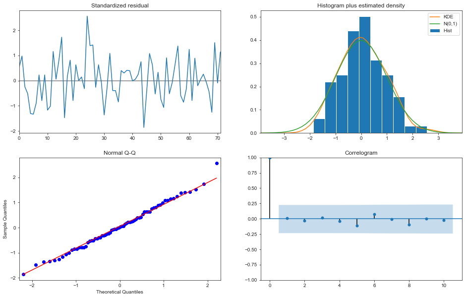

```python
plt.rcParams["figure.figsize"] = [16,10]
sns.set_style("ticks")
result.plot_diagnostics()

plt.savefig('img/4.2 diagnostic_s1.png', dpi=120, bbox_inches='tight')
plt.show()
```

### Simplified SARIMA model

- The Trend of the Time-Serie is non-linear, so we can consider that Trend has very little or no influence in the SARIMA forecast.

```python
# Initialization
data = df.values
order = (0,0,0)
seasonal_order = (2,2,0,12)

# Model
model = SARIMAX(
    data,
    order=order,
    seasonal_order=seasonal_order,
    enforce_stationarity=True,
    enforce_invertibility=False)
result = model.fit()

# Summary
print(result.summary())
```

```
                            Statespace Model Results
================================================================================
Dep. Variable:                        y   No. Observations:                   96
Model:             SARIMAX(2, 2, 0, 12)   Log Likelihood                -655.861
Date:                  Mon, 27 Jan 2020   AIC                           1317.722
Time:                          11:15:16   BIC                           1324.552
Sample:                               0   HQIC                          1320.442
                                   - 96
Covariance Type:                    opg
==============================================================================
                 coef    std err          z      P>|z|      [0.025      0.975]
------------------------------------------------------------------------------
ar.S.L12      -0.0235      0.034     -0.697      0.486      -0.090       0.043
ar.S.L24      -0.0282      0.025     -1.138      0.255      -0.077       0.020
sigma2      4.776e+06   3.97e-10    1.2e+16      0.000    4.78e+06    4.78e+06
===================================================================================
Ljung-Box (Q):                       93.41   Jarque-Bera (JB):                 0.53
Prob(Q):                              0.00   Prob(JB):                         0.77
Heteroskedasticity (H):               0.90   Skew:                            -0.18
Prob(H) (two-sided):                  0.80   Kurtosis:                         2.78
===================================================================================

Warnings:
[1] Covariance matrix calculated using the outer product of gradients (complex-step).
[2] Covariance matrix is singular or near-singular, with condition number 9.59e+31. Standard errors may be unstable.
```

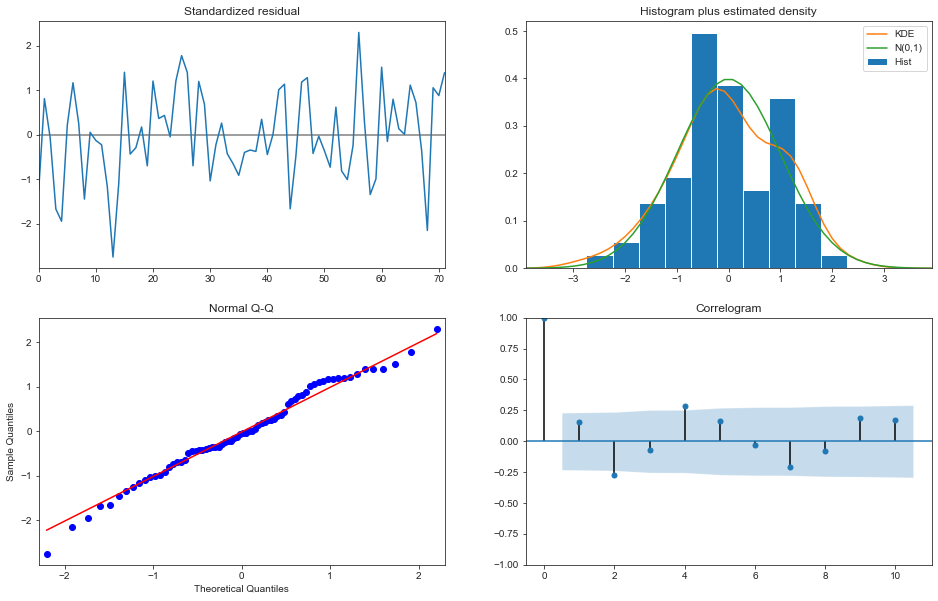

```python
plt.rcParams["figure.figsize"] = [16,10]
sns.set_style("ticks")
result.plot_diagnostics()

plt.savefig('img/4.2 diagnostic_s2.png', dpi=120, bbox_inches='tight')
plt.show()
```

### Auto SARIMA

- pmdarima is a python package that detects the optimal SARIMA model like R's auto.sarima functionality

source: https://alkaline-ml.com/pmdarima/tips_and_tricks.html

```python
# exogenous -> outside factors (e.g other time series)
# m -> seasonal cycle length
# max_order -> maximum amount of variables to be used in the regression (p + q)
# max_p -> maximum AR components
# max_q -> maximum MA components
# max_d -> maximum Integrations
# maxiter -> maximum iterations we're giving the model to converge the coefficients (becomes harder as the order increases)
# alpha -> level of significance, default is 5%, which we should be using most of the time
# n_jobs -> how many models to fit at a time (-1 indicates "as many as possible")
# trend -> "ct" usually
# information_criterion -> 'aic', 'aicc', 'bic', 'hqic', 'oob'
#        (Akaike Information Criterion, Corrected Akaike Information Criterion,
#        Bayesian Information Criterion, Hannan-Quinn Information Criterion, or
#        "out of bag"--for validation scoring--respectively)
# out_of_sample -> validates the model selection (pass the entire dataset, and set 20% to be the out_of_sample_size)
```

```python
# fitting model
model_auto =             auto_arima(df.values, n_jobs = -1,
                         m=12, max_p = 3, max_q = 3,
                         seasonal=True, max_P = 2, Q=0,
                         d=0, D=2, trace=True, alpha = 0.05,
                         error_action='ignore',
                         suppress_warnings=True,
                         stepwise=True)
```

[output not shown]

```python
print(model_auto.summary())
```

```
                                 Statespace Model Results
==========================================================================================
Dep. Variable:                                  y   No. Observations:                   96
Model:             SARIMAX(1, 0, 2)x(0, 2, 1, 12)   Log Likelihood                -635.858
Date:                            Mon, 27 Jan 2020   AIC                           1283.717
Time:                                    11:16:46   BIC                           1297.377
Sample:                                         0   HQIC                          1289.155
                                             - 96
Covariance Type:                              opg
==============================================================================
                 coef    std err          z      P>|z|      [0.025      0.975]
------------------------------------------------------------------------------
intercept     -1.6280     39.107     -0.042      0.967     -78.276      75.020
ar.L1          0.9854      0.078     12.641      0.000       0.833       1.138
ma.L1         -0.7966      0.278     -2.862      0.004      -1.342      -0.251
ma.L2          0.0374      0.207      0.181      0.856      -0.367       0.442
ma.S.L12      -0.9275      0.312     -2.977      0.003      -1.538      -0.317
sigma2      4.086e+06      0.000   4.03e+10      0.000    4.09e+06    4.09e+06
===================================================================================
Ljung-Box (Q):                       83.88   Jarque-Bera (JB):                 0.10
Prob(Q):                              0.00   Prob(JB):                         0.95
Heteroskedasticity (H):               0.97   Skew:                             0.03
Prob(H) (two-sided):                  0.94   Kurtosis:                         2.83
===================================================================================

Warnings:
[1] Covariance matrix calculated using the outer product of gradients (complex-step).
[2] Covariance matrix is singular or near-singular, with condition number 4.92e+26. Standard errors may be unstable.
```

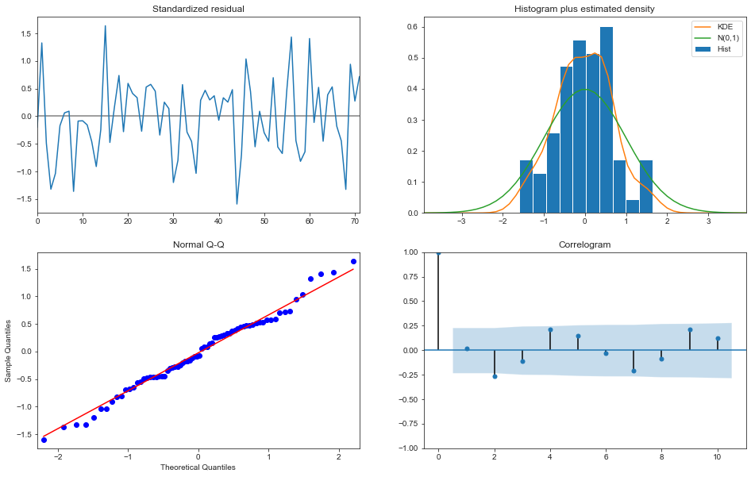

```python
plt.rcParams["figure.figsize"] = [16,10]
sns.set_style("ticks")
model_auto.plot_diagnostics()

plt.savefig('img/4.2 diagnostic_s3.png', dpi=120, bbox_inches='tight')
plt.show()
```

> - The 3 methods present quite similar results in terms of AIC.
> - Auto ARIMA being the best fit without being too complex, we choose it model to pursue our demontration

```python
# Initialization
data = df.values
order = (1, 0, 2)
seasonal_order = (0,2,1,12)

# Model
model = SARIMAX(
    data,
    order=order,
    seasonal_order=seasonal_order,
    enforce_stationarity=True,
    enforce_invertibility=False)
result = model.fit()

# Summary
print(result.summary())

# performances indexes
y_true_sm = df_test
y_pred_sm = pred

print('Retard : p-value')
for elt in [6, 12, 18, 24, 30, 36]:
    print('{} : {}'.format(elt, acorr_ljungbox(result.resid, lags=elt)[1].mean()))
```

```
                                 Statespace Model Results
==========================================================================================
Dep. Variable:                                  y   No. Observations:                   96
Model:             SARIMAX(1, 0, 2)x(0, 2, 1, 12)   Log Likelihood                -629.147
Date:                            Mon, 27 Jan 2020   AIC                           1268.295
Time:                                    11:19:33   BIC                           1279.678
Sample:                                         0   HQIC                          1272.826
                                             - 96
Covariance Type:                              opg
==============================================================================
                 coef    std err          z      P>|z|      [0.025      0.975]
------------------------------------------------------------------------------
ar.L1          0.9999      0.034     29.052      0.000       0.932       1.067
ma.L1         -0.6778      0.134     -5.071      0.000      -0.940      -0.416
ma.L2         -0.0734      0.097     -0.759      0.448      -0.263       0.116
ma.S.L12      -1.0000      0.180     -5.552      0.000      -1.353      -0.647
sigma2       2.02e+06   8.91e-08   2.27e+13      0.000    2.02e+06    2.02e+06
===================================================================================
Ljung-Box (Q):                       72.16   Jarque-Bera (JB):                 0.09
Prob(Q):                              0.00   Prob(JB):                         0.96
Heteroskedasticity (H):               1.02   Skew:                             0.03
Prob(H) (two-sided):                  0.97   Kurtosis:                         2.84
===================================================================================

Warnings:
[1] Covariance matrix calculated using the outer product of gradients (complex-step).
[2] Covariance matrix is singular or near-singular, with condition number 1.72e+29. Standard errors may be unstable.
Retard : p-value
6 : 5.406530223163665e-13
12 : 2.7032652385001294e-13
18 : 1.8021768256667642e-13
24 : 1.3516326192512322e-13
30 : 1.0813060956040992e-13
36 : 9.010884405078374e-14
```

```python
pred_model = result.get_forecast(12)
pred = pred_model.predicted_mean

pred_l = [(elt[0]) for elt in pred_model.conf_int(alpha=0.05)]
pred_u = [(elt[1]) for elt in pred_model.conf_int(alpha=0.05)]
```

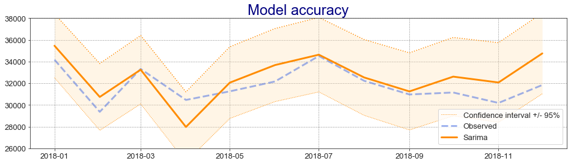

```python
# Graphic
plt.figure(figsize=(16,4))
plt.plot(df_test.index, pred_u, color='darkorange', linestyle=':', linewidth=1.5)
plt.plot(df_test.index, pred_l, color='darkorange', linestyle=':', label="Confidence interval +/- 95%", linewidth=1)
plt.fill_between(df_test.index, pred_l, pred_u, facecolor='navajowhite', alpha=0.3)

plt.plot(df_test, label='Observed',  color='royalblue', linewidth=3, linestyle='--', alpha=0.5)
plt.plot(df_test.index, pred, label='Sarima', color='darkorange', linewidth=3)
plt.legend(fontsize=13)
plt.grid(color="black", linestyle=':', linewidth=0.5)
plt.title("Model accuracy", fontsize=24, color='navy')

plt.ylim(26000,38000)
plt.legend(loc="lower right",fontsize=13)
plt.yticks(fontsize=13)
plt.xticks(fontsize=13)

plt.savefig('img/4.2 model_accuracy.png', dpi=120, bbox_inches='tight')
plt.show()
```

```python
# performances indexes
y_true_sm = df_test
y_pred_sm = pred

# Root mean square error (RMSE)
rmse = sqrt(mean_squared_error(y_true_sm,y_pred_sm))
print("RMSE SARIMA:", round(rmse,3))
# Mean absolute percentage error (MAPE)
mape = np.mean(np.abs((y_true_sm - y_pred_sm) / y_true_sm)) * 100
print("MAPE SARIMA:  ", round(mape,3))
```

```
RMSE SARIMA: 1501.942
MAPE SARIMA:   3.868
```

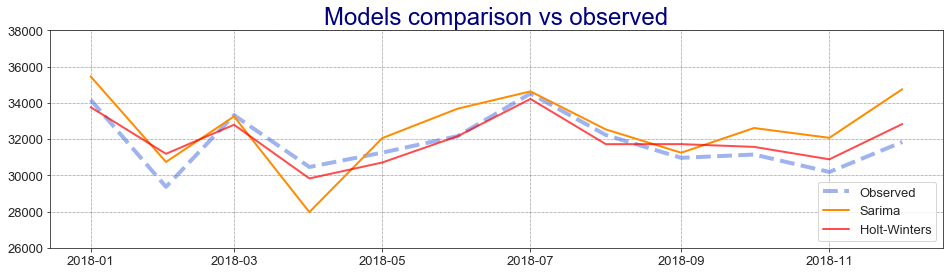

```python
plt.figure(figsize=(16,4))
plt.plot(df_test, label='Observed',  color='royalblue', linewidth=4, linestyle='--', alpha=0.5)
plt.plot(df_test.index, pred, label='Sarima', color='darkorange', linewidth=2)
plt.plot(df_test.index, hw_pred, label='Holt-Winters', linewidth=2, color='red', alpha=0.7)

plt.legend(fontsize=13)
plt.grid(color="black", linestyle=':', linewidth=0.5)
plt.title("Models comparison vs observed", fontsize=24, color='navy')
plt.ylim(26000,38000)

plt.legend(loc="lower right",fontsize=13)
plt.yticks(fontsize=13)
plt.xticks(fontsize=13)

plt.savefig('img/4.2 models_comparison.png', dpi=120, bbox_inches='tight')
plt.show()
```